# la-la-la

Patricia Zito

2023-05-22

Now running it through the ncbi_parser.py script deleted: Tropilaelaps mercedesae OQR69610.1 deleted: Tropilaelaps mercedesae OQR69123.1 out file: no-hexapods-*

Now looking for paralogs. These are the species I’m adding: Sarcoptes scabiei Blomia tropicalis Dermatophagoides farinae Halotydeus destructor Tyrophagus putrescentiae Centruroides sculpturatus Portunus trituberculatus Uloborus diversus Panonychus citri Pollicipes pollicipes

Commands: (base) pzito@IBIO-DRW7N0JQY0 orthologs % blastp -query Sarcoptes-scabiei.fasta -db nr -remote -evalue 0.005 -entrez_query “Sarcoptes scabiei [organism]” -outfmt 6 -out Sarcoptes-scabiei.blastn Warning: (302.10) [blastp] [SOCK::gethostbyaddr] Got “localhost” for local host address (base) pzito@IBIO-DRW7N0JQY0 orthologs % blastp -query Blomia-tropicalis.fasta -db nr -remote -evalue 0.005 -entrez_query “Blomia tropicalis [organism]” -outfmt 6 -out Blomia-tropicalis.blastp Warning: (302.10) [blastp] [SOCK::gethostbyaddr] Got “localhost” for local host address (base) pzito@IBIO-DRW7N0JQY0 orthologs % blastp -query Dermatophagoides-farinae.fasta -db nr -remote -evalue 0.005 -entrez_query “Dermatophagoides farinae [organism]” -outfmt 6 -out Dermatophagoides-farinae.blastp Warning: (302.10) [blastp] [SOCK::gethostbyaddr] Got “localhost” for local host address (base) pzito@IBIO-DRW7N0JQY0 orthologs % blastp -query Halotydeus-destructor.fasta -db nr -remote -evalue 0.005 -entrez_query “Halotydeus destructor [organism]” -outfmt 6 -out Halotydeus-destructor.blastp Warning: (302.10) [blastp] [SOCK::gethostbyaddr] Got “localhost” for local host address (base) pzito@IBIO-DRW7N0JQY0 orthologs % blastp -query Tyrophagus-putrescentiae.fasta -db nr -remote -evalue 0.005 -entrez_query “Tyrophagus putrescentiae [organism]” -outfmt 6 -out Tyrophagus-putrescentiae.blastp Warning: (302.10) [blastp] [SOCK::gethostbyaddr] Got “localhost” for local host address (base) pzito@IBIO-DRW7N0JQY0 orthologs % blastp -query Centruroides-sculpturatus.fasta -db nr -remote -evalue 0.005 -entrez_query “Centruroides sculpturatus [organism]” -outfmt 6 -out Centruroides-sculpturatus.blastp (base) pzito@IBIO-DRW7N0JQY0 orthologs % blastp -query Portunus-trituberculatus.fasta -db nr -remote -evalue 0.005 -entrez_query “Portunus trituberculatus [organism]” -outfmt 6 -out Portunus-trituberculatus.blastp (base) pzito@IBIO-DRW7N0JQY0 orthologs % blastp -query Panonychus-citri.fasta -db nr -remote -evalue 0.005 -entrez_query “Panonychus citri [organism]” -outfmt 6 -out Panonychus-citri.blastp (base) pzito@IBIO-DRW7N0JQY0 orthologs % blastp -query Pollicipes-pollicipes.fasta -db nr -remote -evalue 0.005 -entrez_query “Pollicipes pollicipes [organism]” -outfmt 6 -out Pollicipes-pollicipes.blastp

Now adding all paralogs manually on the non-conserved dataframe. Copied from: orthologs-filtered-ALL+outgroups.csv

Added all the sub-phyla and order information. Maybe now I should delete the duplicates. Ok making a new R file.

### 1. Remove Duplicates!

```r
data <- read.csv("orthologs-filtered-ALL+outgroups.csv")
dim(data)
```

```
## [1] 310   9
```

```r
duplicates <- duplicated(data$protein.accession)
data2 <- data[!duplicates,]
dim(data2)
```

```
## [1] 221   9
```

got rid of 89 duplicates! wowowowow!

```r
write.csv(data2, file="orthologs-filtered-ALL+outgroups-duplicates.csv")
```

### 2. Remove potential NHE sequences!

get the drosophila sequences because I’m tired of having the same fasta copies on all my folders

```r
library(rentrez)
nha2 <- entrez_fetch(db="protein", id="NP_001247251.1", rettype="fasta")
nha2
```

```
## [1] ">NP_001247251.1 Na[+]/H[+] hydrogen antiporter 2, isoform B [Drosophila melanogaster]\nMSSDSDILDVVAGSEGPPLQAFRSSNPFEDSYQMSSCQQDFERDRDANLTPLHMLRRASETVTASILEPE\nKEHLLGDKPQVPPRAHGSTAPSAIEAKRSRQQPNQWQLQQQQQPSSNNNNTKRALAPGDNMTQGAAPQDS\nQGDILPTRPLHTKLDIQKIPEDEAGADATQNAATIILTPTSLNLTNTTTQNVAANNAGNSS…
```

```r
nhe3 <- entrez_fetch(db="protein", id="AAF13702.1", rettype="fasta")
nhe3
```

```
## [1] ">AAF13702.1 sodium-hydrogen exchanger NHE3 [Drosophila melanogaster]\nMLLIVGFALCVLAPGCSATDTDIALDAKATLNHRIQSLDLLVFVFLLALTVLTIWLFKHHRVSWLHETGL\nAVIYGLIVGAIIRYAGTSGTLDHMQVEPQGVPTYSDKLPPDTLWFRYPVNQTNGTKPPEGIKTYAYVFRG\nQVHDVDENEIDLKATFDPEVFFNIILPPIIFYAGYCLKKKYFFRNLGAILTFAIVGTTLSAFLIGGFMYG\nCVKLMP…
```

```r
# one of the issues here is that this comes with the original header
# when I transform this into an AAString object, it understands the header as part of the sequence
# so I have to remove that because it won't be alignable

# 1st: remove all spaces "\n"
nha2 <- gsub(pattern="\n", replacement="", nha2)
nha2
```

```
## [1] ">NP_001247251.1 Na[+]/H[+] hydrogen antiporter 2, isoform B [Drosophila melanogaster]MSSDSDILDVVAGSEGPPLQAFRSSNPFEDSYQMSSCQQDFERDRDANLTPLHMLRRASE…"
```

```r
nhe3 <- gsub(pattern="\n", replacement="",nhe3)
nhe3
```

```
## [1] ">AAF13702.1 sodium-hydrogen exchanger NHE3 [Drosophila melanogaster]MLLIVGFALCVLAPGCSATDTDIALDAKATLNHRIQSLDLLVFVFLLALTVLTIWLFKHH…"
```

```r
# 2nd: remove the header and turn these into XString()
start_nha2 <- nchar(">NP_001247251.1 Na[+]/H[+] hydrogen antiporter 2, isoform B [Drosophila melanogaster]")
start_nhe3 <- nchar(">AAF13702.1 sodium-hydrogen exchanger NHE3 [Drosophila melanogaster]")
Dmelnha2 <- AAString(nha2, start = start_nha2+1)
Dmelnhe3 <- AAString(substr(nhe3, 69, 755))

# ok let's see how they look!
Dmelnha2
```

```
## 714-letter AAString object
## seq: MSSDSDILDVVAGSEGPPLQAFRSSNPFEDSYQMSS...RLAPYWLKHGDAVEAVDSPTTPIAPTLGSTNSSKGT
```

```r
Dmelnhe3
```

```
## 687-letter AAString object
## seq: MLLIVGFALCVLAPGCSATDTDIALDAKATLNHRIQ...NDTGNGLSQDGSGAAPGVGRRNSLSRVGGDHRNAYI
```

```r
# align sequences
remove_NHE <- function(df){
  gap_open <- -10
  gap_extent <- -1
  index_list <- c()
  NHA.scores <- c()
  NHE.scores <- c()

  seq_name = df$protein.accession
  sequence = df$protein.sequence

  for(i in 1:length(sequence)){
    removed <- gsub("\n", "", toupper(sequence[i])) # remove skip lines
    seq <- AAString(gsub("`", "", removed)) # remove this weird thing that one of the sequences have
    NHE_score <- pairwiseAlignment(Dmelnhe3, seq, type = "global", substitutionMatrix = "BLOSUM50", gapOpening = gap_open, gapExtension = gap_extent, scoreOnly = TRUE)
    NHE.scores <- append(NHE.scores, NHE_score)
    NHA_score <- pairwiseAlignment(Dmelnha2, seq, type = "global", substitutionMatrix = "BLOSUM50", gapOpening = gap_open, gapExtension = gap_extent, scoreOnly = TRUE)
    NHA.scores <- append(NHA.scores, NHA_score)
  }
  df2 <- df[-which(data2$protein.accession %in% seq_name[index_list]),]
  df2 <- cbind(df, NHA.scores, NHE.scores)
  return(df2)
}

data3 <- remove_NHE(data2) # ok the code flagged down a couple of sequences with really bad alignments
dim(data3)
```

```
## [1] 221  11
```

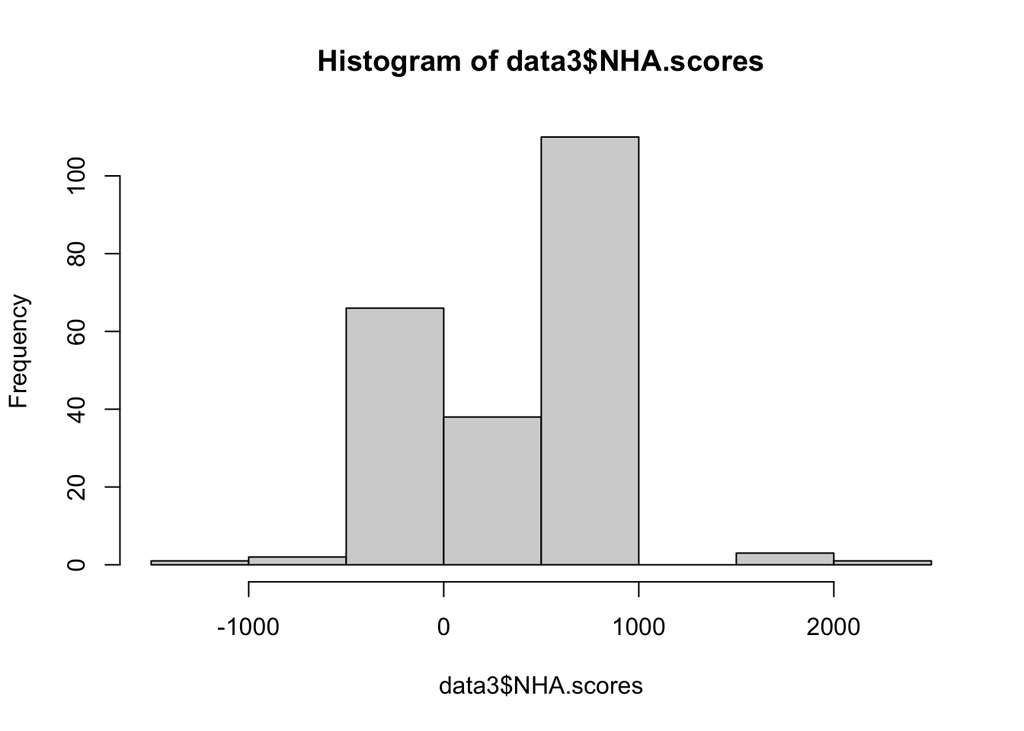

```r
# before filtering
hist(data3$NHA.scores)
```

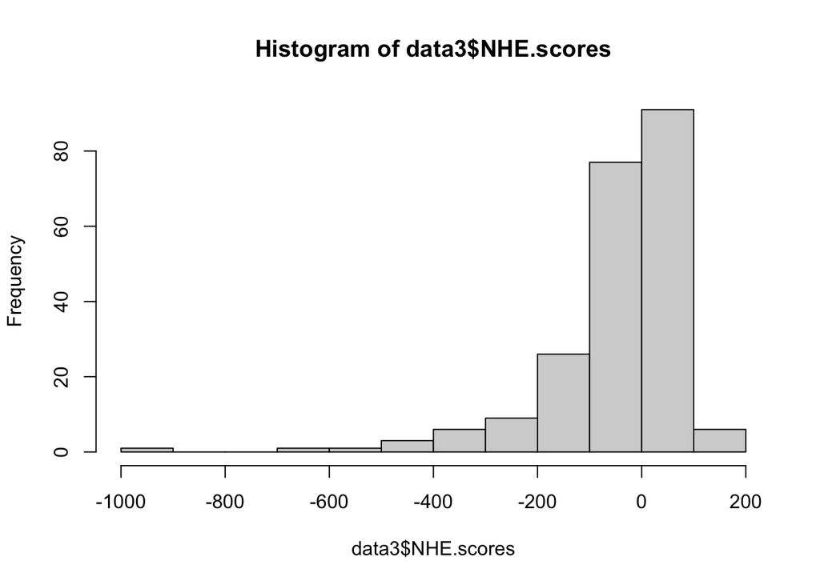

```r
hist(data3$NHE.scores)
```

```r
# after filtering
data4 <- data3 %>% filter(NHA.scores > NHE.scores) # if the NHE score was higher
dim(data4)
```

```
## [1] 170  11
```

```r
mean(data4$NHA.scores)
```

```
## [1] 607.9235
```

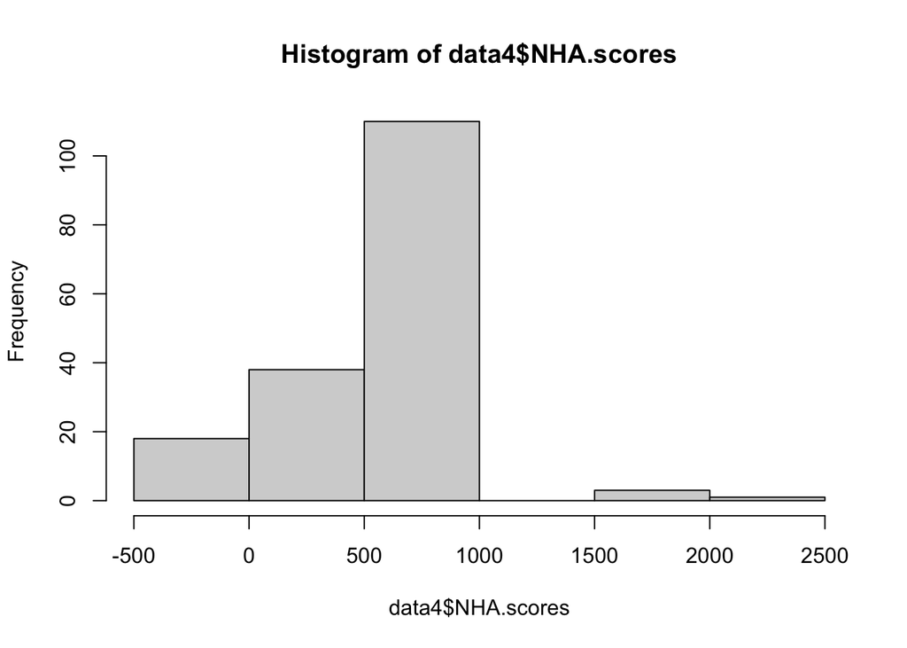

```r
hist(data4$NHA.scores)
```

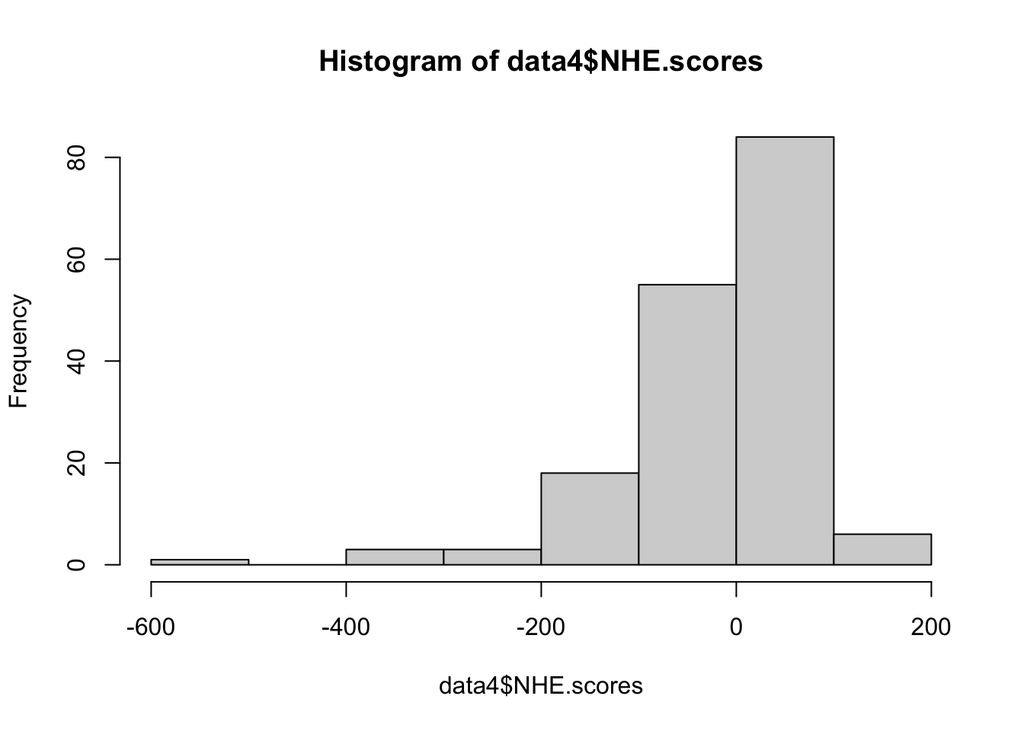

```r
hist(data4$NHE.scores)
```

```r
write.csv(data4, file="orthologs-filtered-ALL+outgroups-duplicates-NHE1.csv")
```

### 3. get positions of these sequences!

I’ll be doing this manually because rentrez is incapable of doing it :) also adding the CDS sequences, start, end and number of exons. all of this will be available on the “orthologs-filtered-ALL+outgroups-duplicates-NHE1.csv” file.

### 3.1 adding the last bit of species?

I’m looking to see if there are any more Daphnea species that could have NHA. right now blasting back the only Daphnea sinensis sequence present in the dataset.

command Daphnia: (base) pzito@IBIO-DRW7N0JQY0 extra-blasts % blastp -query Daphnea-sisensis.fasta -db nr -remote -evalue 0.005 -entrez_query “Daphnia [organism]” -outfmt 6 -out Daphnea.blastn

result: only the only we already have. and now that I look at it, the NHA score isn’t that good (-106). It’s higher than NHE, but it definitely doesn’t look too good.

### 4. see which “paralogs” are actually just different transcripts

Genbank has a lot of different protein entries. taking the direct results from the ncbi search will overestimate the number of paralog sequences in species. To check whether these are paralogues and not different transcripts, I’ll be checking to see if there are overlaps between the the sequences. If there is, I’ll have to align them and collapse them. (make a new frankenstein CDS sequence that contains all potentially code-able regions).

```r
data5 <- read.csv("orthologs-filtered-ALL+outgroups-duplicates-NHE1.csv", header = TRUE)

# see what it looks like so far
nrow(data5) # number of sequences
```

```
## [1] 163
```

```r
length(unique(data5$species)) # number of species
```

```
## [1] 45
```

```r
unique(data5$subphyla)
```

```
## [1] "(hexapoda)"    "(crustacea)"   "(chelicerata)" "(tardigrada)"
```

```r
unique(data5[which(data5$subphyla=="(hexapoda)"),]$species) # all hexapods species
```

```
##  [1] "Cloeon dipterum"           "Cotesia congregata"
##  [3] "Iphiclides podalirius"     "Ampulex compressa"
##  [5] "Brenthis ino"              "Blomia tropicalis"
##  [7] "Ooceraea biroi"            "Apolygus lucorum"
##  [9] "Polypedilum vanderplanki"  "Lucilia cuprina"
## [11] "Nezara viridula"           "Ceratitis capitata"
## [13] "Helicoverpa armigera"      "Vespula vulgaris"
## [15] "Temnothorax longispinosus" "Dendrolimus kikuchii"
## [17] "Acromyrmex echinatior"     "Spodoptera littoralis"
## [19] "Ephemera danica"           "Arctia plantaginis"
## [21] "Periplaneta americana"     "Diaphorina citri"
## [23] "Eciton burchellii"         "Megalurothrips usitatus"
## [25] "Anopheles gambiae"
```

```r
unique(data5[which(data5$subphyla=="(chelicerata)"),]$species) # all chelicerates species
```

```
## [1] "Nymphon striatum"          "Oedothorax gibbosus"
## [3] "Dermatophagoides farinae"  "Sarcoptes scabiei"
## [5] "Centruroides sculpturatus" "Halotydeus destructor"
## [7] "Panonychus citri"          "Tyrophagus putrescentiae"
## [9] "Uloborus diversus"
```

```r
unique(data5[which(data5$subphyla=="(crustacea)"),]$species) # all crustacean species
```

```
## [1] "Tigriopus californicus"   "Hyalella azteca"
## [3] "Lepeophtheirus salmonis"  "Idotea baltica"
## [5] "Daphnia sinensis"         "Amphibalanus amphitrite"
## [7] "Penaeus vannamei"         "Pollicipes pollicipes"
## [9] "Portunus trituberculatus"
```

```r
unique(data5[which(data5$subphyla=="(tardigrada)"),]$species) # all tardigrada species
```

```
## [1] "Hypsibius exemplaris"      "Ramazzottius varieornatus"
```

first find which species and which sequences there is an overlap:

```r
all_species <- unique(data5$species)
for(i in 1:length(all_species)){
  print(all_species[i])
  df <- data5[which(data5$species == all_species[i]),]
  overlapped <- c()
  if(nrow(df)>1){
    comb <- combn(df$protein.accession, m=2)
    for(col in 1:ncol(comb)){
      row1 <- df[which(df$protein.accession==comb[1, col]),]
      row2 <- df[which(df$protein.accession==comb[2, col]),]
      no_NA <- !is.na(row1$CDS.start)
      same_scaff <- row1$scaffold==row2$scaffold
      overlap <- range(row1$CDS.start, row1$CDS.end) %overlaps% range(row2$CDS.start, row2$CDS.end)
      if(no_NA && same_scaff && overlap){
        overlapped <- append(overlapped, col)
      }
    }
  }
  if(length(overlapped)>0){
    print("OVERLAPPED!")
    print(comb[,overlapped])
  }
}
```

```
## [1] "Cloeon dipterum"
## [1] "OVERLAPPED!"
##      [,1]                [,2]                [,3]
## [1,] "emb|CAB3360254.1|" "emb|CAB3360254.1|" "emb|CAB3360254.1|"
## [2,] "emb|CAB3360255.1|" "emb|CAB3360256.1|" "emb|CAB3360257.1|"
##      [,4]                [,5]                [,6]
## [1,] "emb|CAB3360254.1|" "emb|CAB3360255.1|" "emb|CAB3360255.1|"
## [2,] "emb|CAB3360258.1|" "emb|CAB3360256.1|" "emb|CAB3360257.1|"
##      [,7]                [,8]                [,9]
## [1,] "emb|CAB3360255.1|" "emb|CAB3360256.1|" "emb|CAB3360256.1|"
## [2,] "emb|CAB3360258.1|" "emb|CAB3360257.1|" "emb|CAB3360258.1|"
##      [,10]
## [1,] "emb|CAB3360257.1|"
## [2,] "emb|CAB3360258.1|"
## [1] "Tigriopus californicus"
```

[output cut: 100 more lines]

can probably collapse these by the duplicated add seq1 + seq2 -overlap(seq1, seq2) > from alignment